# Hotel Booking Cancellation Business Analytics Report

## Executive Summary

This report examines hotel booking cancellation behaviour across City Hotel and Resort Hotel reservations. The purpose is to support hotel management in improving revenue stability, occupancy planning, pricing decisions, and customer retention strategies.

The analysis shows that cancellation behaviour is not evenly distributed across hotel type, customer type, booking channel, deposit policy, customer history, and room type. City Hotel records a much higher cancellation rate than Resort Hotel, while new customers, selected source markets, specific deposit types, and selected room categories show higher cancellation exposure.

From a management perspective, the most important business issue is not simply whether customers cancel, but which customer groups, booking conditions, and operational factors increase cancellation risk. These findings can support more targeted deposit policies, customer communication strategies, room information validation, seasonal pricing decisions, and retention programs.

## Business Context

Hotel cancellations directly affect revenue management, demand forecasting, staffing, inventory allocation, and customer service planning. A reservation that is cancelled close to the arrival date may create lost revenue if the room cannot be resold. High cancellation rates also make it harder for hotels to plan occupancy, staffing levels, and pricing strategies.

For hotel operators, a cancellation analytics report can answer practical business questions such as:

- Which hotel type has the greater cancellation risk?
- Which customer segments contribute most to cancellations?
- Which booking channels and deposit policies are associated with higher cancellation rates?
- Which months and source markets should receive more management attention?
- What actions can reduce revenue uncertainty and improve booking reliability?

### Business Objectives

The objectives of this report are to:

- Assess booking volume and cancellation patterns by hotel type.
- Identify seasonal demand patterns across the year.
- Compare cancellation behaviour across source countries, customer types, booking channels, deposit policies, and room types.
- Translate analytical findings into practical recommendations for hotel management.
- Build a predictive modelling baseline to estimate whether a booking is likely to be cancelled.

## Dataset Description

The dataset contains reservation-level records for City Hotel and Resort Hotel bookings. Each record represents a booking and includes information about reservation timing, length of stay, customer type, booking channel, pricing, deposit policy, special requests, room allocation, and final reservation status.

The target outcome for cancellation analysis is `is_canceled`, where `1` means the booking was cancelled and `0` means the booking was not cancelled.

## Data Dictionary

| Field | Business Meaning |
| --- | --- |
| hotel | Hotel category, either City Hotel or Resort Hotel. |
| is_canceled | Cancellation outcome. 1 means the booking was cancelled; 0 means it was not cancelled. |
| lead_time | Number of days between booking creation and arrival. Longer lead time may indicate higher uncertainty. |
| arrival_date_year | Year of scheduled arrival. |
| arrival_date_month | Month of scheduled arrival, useful for seasonality analysis. |
| arrival_date_week_number | Week number of scheduled arrival. |
| arrival_date_day_of_month | Day of month of scheduled arrival. |
| stays_in_weekend_nights | Number of weekend nights included in the stay. |
| stays_in_week_nights | Number of weekday nights included in the stay. |
| adults | Number of adult guests. |
| children | Number of children guests. |
| babies | Number of baby guests. |
| meal | Meal package selected by the customer. |
| country | Customer country of origin. |
| market_segment | Market segment through which the booking was made. |
| distribution_channel | Distribution channel used for the booking. |
| is_repeated_guest | Whether the customer is a returning guest. |
| previous_cancellations | Number of previous cancellations by the customer. |
| previous_bookings_not_canceled | Number of previous non-cancelled bookings by the customer. |
| reserved_room_type | Room type originally reserved. |
| assigned_room_type | Room type finally assigned. |
| booking_changes | Number of changes made to the booking. |
| deposit_type | Deposit policy applied to the booking. |
| agent | Travel agency identifier. |
| company | Company identifier. |
| days_in_waiting_list | Number of days the booking stayed on the waiting list. |
| customer_type | Customer category, such as transient, contract, group, or transient-party. |
| adr | Average Daily Rate, representing daily room revenue per booking. |
| required_car_parking_spaces | Number of car parking spaces requested. |
| total_of_special_requests | Number of special requests made by the customer. |
| reservation_status | Final reservation status. |
| reservation_status_date | Date when the reservation status was last updated. |

## Methodology

The report follows a business analytics workflow:

- **Data understanding**: inspect structure, missing values, distributions, and business meaning of fields.
- **Exploratory analysis**: compare booking and cancellation patterns across hotels, months, countries, customer types, channels, deposit policies, and room types.
- **Business interpretation**: convert each analytical result into management implications.
- **Predictive modelling baseline**: train classification models to estimate cancellation likelihood.
- **Recommendations**: propose actions to reduce cancellation risk and improve operational planning.g.

# 1. Data Understanding

This section reviews the structure and quality of the dataset before business analysis. The purpose is to understand whether the data is suitable for cancellation analysis and to identify fields that require cleaning or transformation.

|  | hotel | is_canceled | lead_time | arrival_date_year | arrival_date_month | arrival_date_week_number | arrival_date_day_of_month | stays_in_weekend_nights | stays_in_week_nights | adults | ... | deposit_type | agent | company | days_in_waiting_list | customer_type | adr | required_car_parking_spaces | total_of_special_requests | reservation_status | reservation_status_date |
| --- | --- | --- | --- | --- | --- | --- | --- | --- | --- | --- | --- | --- | --- | --- | --- | --- | --- | --- | --- | --- | --- |
| 0 | Resort Hotel | 0 | 342 | 2015 | July | 27 | 1 | 0 | 0 | 2 | ... | No Deposit | NaN | NaN | 0 | Transient | 0.0 | 0 | 0 | Check-Out | 2015-07-01 |
| 1 | Resort Hotel | 0 | 737 | 2015 | July | 27 | 1 | 0 | 0 | 2 | ... | No Deposit | NaN | NaN | 0 | Transient | 0.0 | 0 | 0 | Check-Out | 2015-07-01 |
| 2 | Resort Hotel | 0 | 7 | 2015 | July | 27 | 1 | 0 | 1 | 1 | ... | No Deposit | NaN | NaN | 0 | Transient | 75.0 | 0 | 0 | Check-Out | 2015-07-02 |
| 3 | Resort Hotel | 0 | 13 | 2015 | July | 27 | 1 | 0 | 1 | 1 | ... | No Deposit | 304.0 | NaN | 0 | Transient | 75.0 | 0 | 0 | Check-Out | 2015-07-02 |
| 4 | Resort Hotel | 0 | 14 | 2015 | July | 27 | 1 | 0 | 2 | 2 | ... | No Deposit | 240.0 | NaN | 0 | Transient | 98.0 | 0 | 1 | Check-Out | 2015-07-03 |

5 rows × 32 columns

```
hotel                             0.000000
is_canceled                       0.000000
lead_time                         0.000000
arrival_date_year                 0.000000
arrival_date_month                0.000000
arrival_date_week_number          0.000000
arrival_date_day_of_month         0.000000
stays_in_weekend_nights           0.000000
stays_in_week_nights              0.000000
adults                            0.000000
children                          0.000034
babies                            0.000000
meal                              0.000000
country                           0.004087
market_segment                    0.000000
distribution_channel              0.000000
is_repeated_guest                 0.000000
previous_cancellations            0.000000
previous_bookings_not_canceled    0.000000
reserved_room_type                0.000000
assigned_room_type                0.000000
booking_changes                   0.000000
deposit_type                      0.000000
agent                             0.136862
company                           0.943069
days_in_waiting_list              0.000000
customer_type                     0.000000
adr                               0.000000
required_car_parking_spaces       0.000000
total_of_special_requests         0.000000
reservation_status                0.000000
reservation_status_date           0.000000
dtype: float64
```

```
<class 'pandas.DataFrame'>
RangeIndex: 119390 entries, 0 to 119389
Data columns (total 32 columns):
 #   Column                          Non-Null Count   Dtype
---  ------                          --------------   -----
 0   hotel                           119390 non-null  str
 1   is_canceled                     119390 non-null  int64
 2   lead_time                       119390 non-null  int64
 3   arrival_date_year               119390 non-null  int64
 4   arrival_date_month              119390 non-null  str
 5   arrival_date_week_number        119390 non-null  int64
 6   arrival_date_day_of_month       119390 non-null  int64
 7   stays_in_weekend_nights         119390 non-null  int64
 8   stays_in_week_nights            119390 non-null  int64
 9   adults                          119390 non-null  int64
```

[output cut: 24 more lines]

|  | count | mean | std | min | 1% | 5% | 10% | 25% | 50% | 75% | 99% | max |
| --- | --- | --- | --- | --- | --- | --- | --- | --- | --- | --- | --- | --- |
| is_canceled | 119390.0 | 0.370416 | 0.482918 | 0.00 | 0.0 | 0.0 | 0.0 | 0.00 | 0.000 | 1.0 | 1.00 | 1.0 |
| lead_time | 119390.0 | 104.011416 | 106.863097 | 0.00 | 0.0 | 0.0 | 3.0 | 18.00 | 69.000 | 160.0 | 444.00 | 737.0 |
| arrival_date_year | 119390.0 | 2016.156554 | 0.707476 | 2015.00 | 2015.0 | 2015.0 | 2015.0 | 2016.00 | 2016.000 | 2017.0 | 2017.00 | 2017.0 |
| arrival_date_week_number | 119390.0 | 27.165173 | 13.605138 | 1.00 | 2.0 | 5.0 | 8.0 | 16.00 | 28.000 | 38.0 | 53.00 | 53.0 |
| arrival_date_day_of_month | 119390.0 | 15.798241 | 8.780829 | 1.00 | 1.0 | 2.0 | 4.0 | 8.00 | 16.000 | 23.0 | 31.00 | 31.0 |
| stays_in_weekend_nights | 119390.0 | 0.927599 | 0.998613 | 0.00 | 0.0 | 0.0 | 0.0 | 0.00 | 1.000 | 2.0 | 4.00 | 19.0 |
| stays_in_week_nights | 119390.0 | 2.500302 | 1.908286 | 0.00 | 0.0 | 0.0 | 1.0 | 1.00 | 2.000 | 3.0 | 10.00 | 50.0 |
| adults | 119390.0 | 1.856403 | 0.579261 | 0.00 | 1.0 | 1.0 | 1.0 | 2.00 | 2.000 | 2.0 | 3.00 | 55.0 |
| children | 119386.0 | 0.103890 | 0.398561 | 0.00 | 0.0 | 0.0 | 0.0 | 0.00 | 0.000 | 0.0 | 2.00 | 10.0 |
| babies | 119390.0 | 0.007949 | 0.097436 | 0.00 | 0.0 | 0.0 | 0.0 | 0.00 | 0.000 | 0.0 | 0.00 | 10.0 |
| is_repeated_guest | 119390.0 | 0.031912 | 0.175767 | 0.00 | 0.0 | 0.0 | 0.0 | 0.00 | 0.000 | 0.0 | 1.00 | 1.0 |
| previous_cancellations | 119390.0 | 0.087118 | 0.844336 | 0.00 | 0.0 | 0.0 | 0.0 | 0.00 | 0.000 | 0.0 | 1.00 | 26.0 |
| previous_bookings_not_canceled | 119390.0 | 0.137097 | 1.497437 | 0.00 | 0.0 | 0.0 | 0.0 | 0.00 | 0.000 | 0.0 | 3.00 | 72.0 |
| booking_changes | 119390.0 | 0.221124 | 0.652306 | 0.00 | 0.0 | 0.0 | 0.0 | 0.00 | 0.000 | 0.0 | 3.00 | 21.0 |
| agent | 103050.0 | 86.693382 | 110.774548 | 1.00 | 1.0 | 1.0 | 6.0 | 9.00 | 14.000 | 229.0 | 390.00 | 535.0 |
| company | 6797.0 | 189.266735 | 131.655015 | 6.00 | 16.0 | 40.0 | 40.0 | 62.00 | 179.000 | 270.0 | 513.04 | 543.0 |
| days_in_waiting_list | 119390.0 | 2.321149 | 17.594721 | 0.00 | 0.0 | 0.0 | 0.0 | 0.00 | 0.000 | 0.0 | 75.00 | 391.0 |
| adr | 119390.0 | 101.831122 | 50.535790 | -6.38 | 0.0 | 38.4 | 50.0 | 69.29 | 94.575 | 126.0 | 252.00 | 5400.0 |
| required_car_parking_spaces | 119390.0 | 0.062518 | 0.245291 | 0.00 | 0.0 | 0.0 | 0.0 | 0.00 | 0.000 | 0.0 | 1.00 | 8.0 |
| total_of_special_requests | 119390.0 | 0.571363 | 0.792798 | 0.00 | 0.0 | 0.0 | 0.0 | 0.00 | 0.000 | 1.0 | 3.00 | 5.0 |

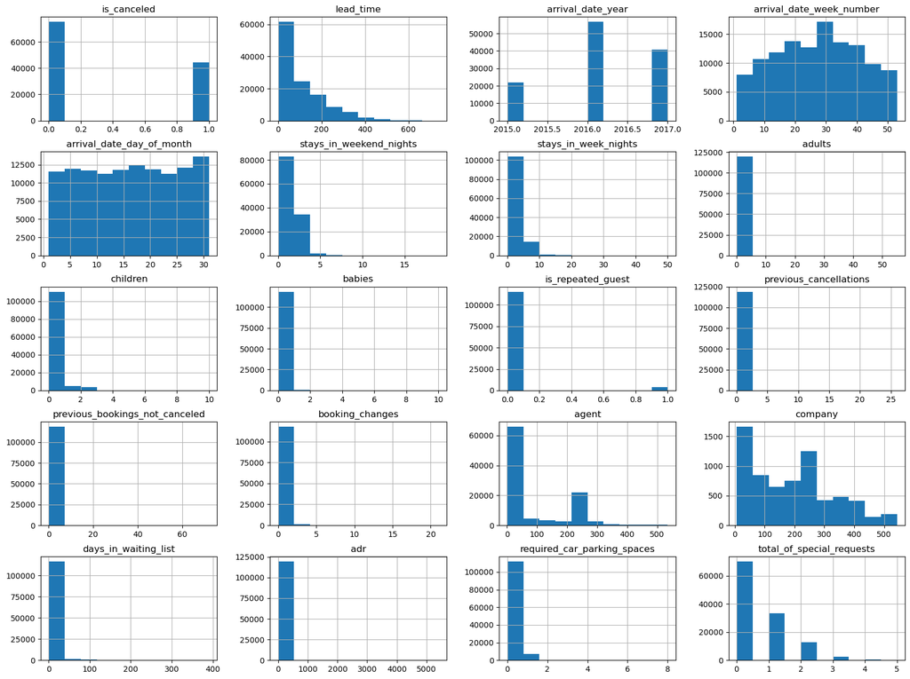

# 2. Exploratory Business Analysis

This section presents the main business findings from the hotel booking data. Each analysis focuses on a practical management question and translates the result into business implications.

## 2.1 Booking Volume and Cancellation Rate by Hotel Type

**Business question:** Which hotel type faces greater cancellation pressure?

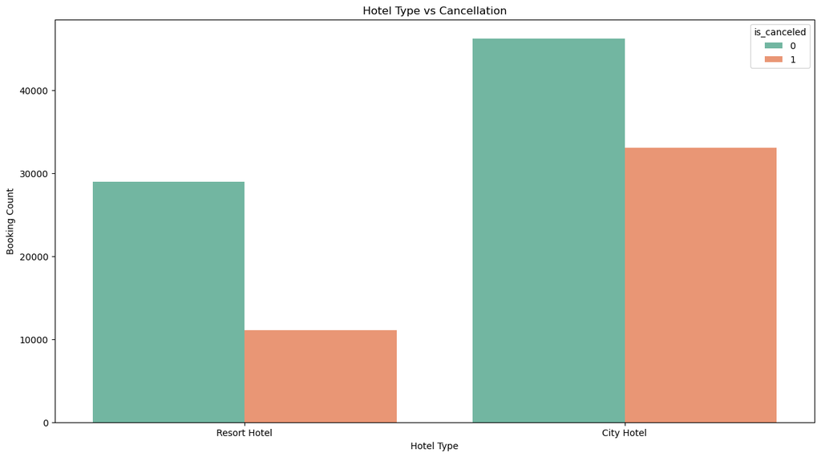

|  | Hotel Type | Cancellation Rate |
| --- | --- | --- |
| 0 | City Hotel | 0.417270 |
| 1 | Resort Hotel | 0.277634 |

**Finding and Business Impact**

City Hotel has both higher booking volume and higher cancellation volume than Resort Hotel. The cancellation rate of City Hotel is approximately 41.7%, compared with approximately 27.8% for Resort Hotel. This suggests that City Hotel faces greater revenue uncertainty and should be the priority segment for cancellation reduction initiatives.

## 2.2 Monthly Booking Demand

**Business question:** When do hotels experience peak demand, and how can seasonality support pricing and staffing decisions?

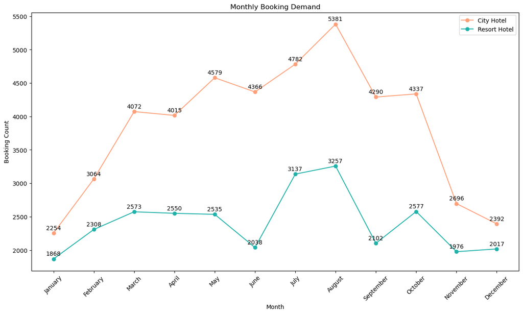

**Finding and Business Impact**

These findings suggest that hotels should align pricing, staffing, and marketing strategies with seasonal demand changes. Peak-demand periods may justify higher pricing and increased staffing, while lower-demand months may require promotions to improve occupancy.

## 2.3 Source Market and Cancellation Rate

**Business question:** Which customer origin markets are most important, and which markets show higher cancellation risk?

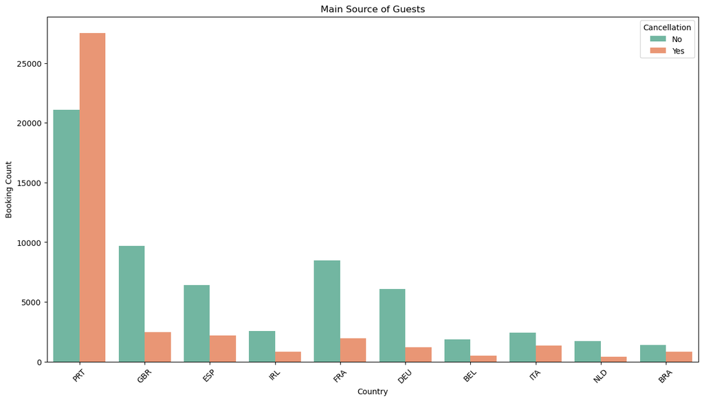

|  | Country | Cancellation Rate |
| --- | --- | --- |
| 0 | PRT | 56.64% |
| 1 | BRA | 37.32% |
| 2 | ITA | 35.4% |
| 3 | ESP | 25.41% |
| 4 | IRL | 24.65% |
| 5 | BEL | 20.24% |
| 6 | GBR | 20.22% |
| 7 | FRA | 18.57% |
| 8 | NLD | 18.39% |
| 9 | DEU | 16.71% |

**Finding and Business Impact**

The hotel customer base is primarily concentrated in European markets, with Portugal (PRT), the United Kingdom (GBR), France (FRA), and Spain (ESP) contributing the highest booking volumes. Portugal not only generates the largest number of bookings but also records the highest cancellation rate among major markets.

These findings suggest that hotel management should closely monitor high-volume and high-cancellation markets, particularly Portugal. Targeted communication strategies, stricter deposit policies, and improved booking validation processes may help reduce cancellation-related revenue uncertainty.

## 2.4 Customer Type Analysis

**Business question:** Which customer groups dominate hotel demand?

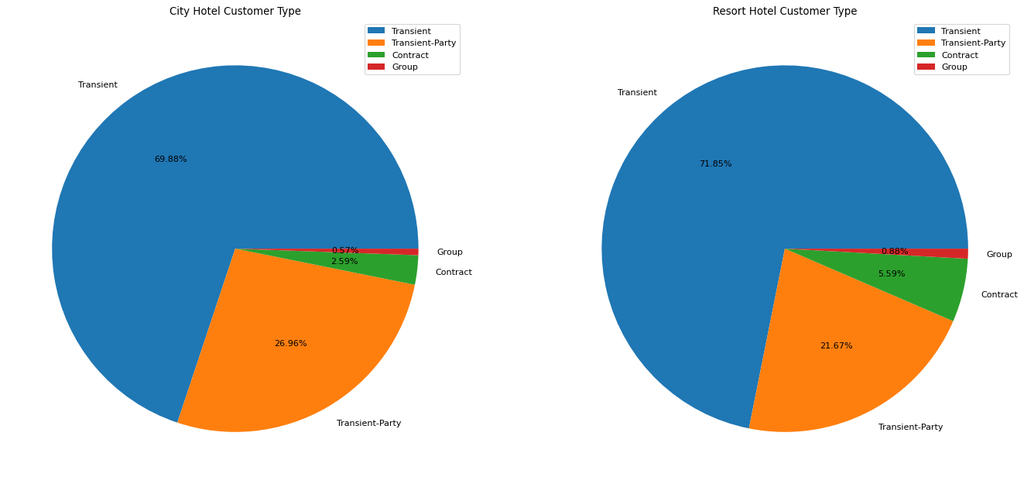

**Finding and Business Impact**

Transient customers dominate hotel demand for both City Hotel and Resort Hotel, accounting for approximately 70% of total bookings. Transient-Party customers represent the second largest segment, while Contract and Group customers contribute only a small proportion of bookings.

These findings indicate that hotel operations and revenue strategies are heavily dependent on individual and flexible travellers. As transient customers typically have more flexible booking behaviour, hotels should prioritise customer communication, pricing optimisation, and cancellation management strategies for this segment.

## 2.5 Booking Channel Analysis

**Business question:** Which booking channels generate the most reservations?

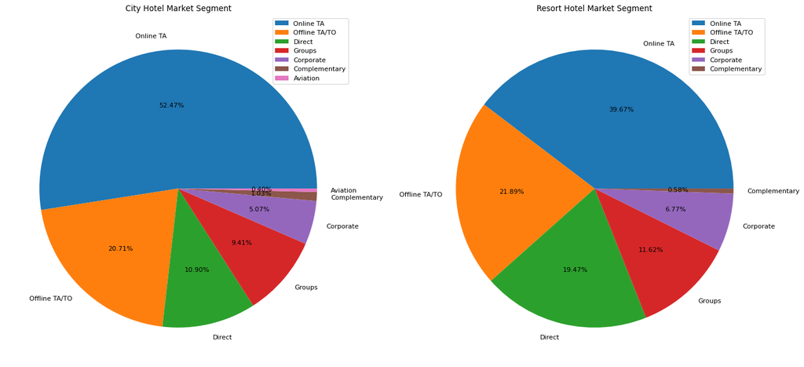

**Finding and Business Impact**

Online travel agencies (Online TA) are the dominant booking channel for both hotel types, particularly for City Hotel, where they contribute more than half of total reservations. Offline travel agencies also remain an important secondary source, while Resort Hotel shows a relatively higher proportion of direct bookings.

These findings suggest that booking channel management plays a critical role in revenue generation and customer acquisition. Hotels should maintain strong visibility on online travel platforms while also encouraging direct bookings to reduce commission costs and improve customer relationship management.

## 2.6 Average Daily Rate by Customer Type

**Business question:** Which customer groups generate higher daily room revenue?

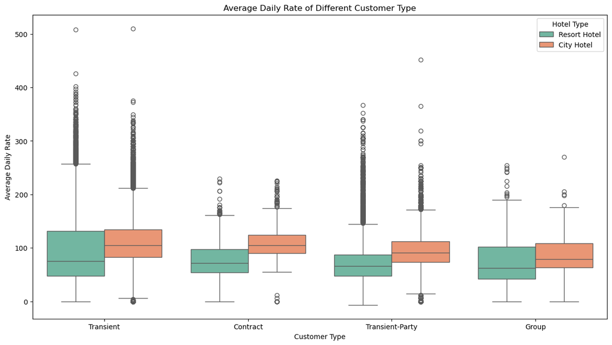

**Finding and Business Impact**

City Hotel records consistently higher average daily rates (ADR) than Resort Hotel across all customer groups. Among customer types, transient customers generate the highest room revenue, while group customers show the lowest ADR levels.

These findings suggest that transient customers are both the largest and most valuable revenue segment for hotels. Hotels may prioritise pricing optimisation, loyalty programs, and personalised marketing strategies for transient customers to maximise room revenue and profitability.

## 2.7 Repeated Guests and Cancellation Behaviour

**Business question:** Do returning customers behave differently from new customers?

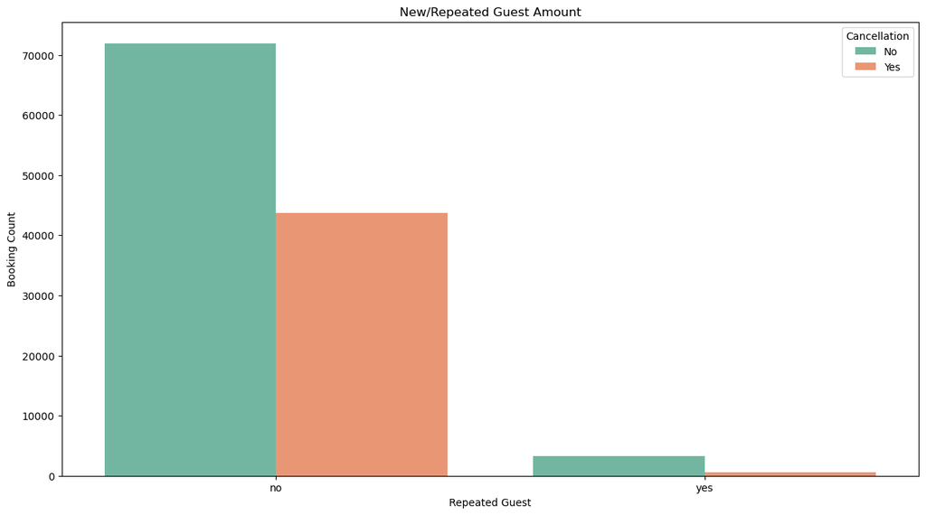

|  | Guest Type | Cancellation Rate |
| --- | --- | --- |
| 0 | New Guest | 37.79% |
| 1 | Repeated Guest | 14.49% |

**Finding and Business Impact**

The analysis shows that repeated guests make up a much smaller share of total bookings, but they are significantly more stable than new guests. New guests have a cancellation rate of about 37.8%, while repeated guests have a much lower cancellation rate of around 14.5%.

Repeated guests are more reliable and less likely to cancel than new guests. This suggests that customer loyalty programs and retention strategies may help reduce cancellation risk and improve revenue stability.

## 2.8 Deposit Policy and Cancellation Risk

**Business question:** How does deposit policy affect cancellation behaviour?

|  | Deposit Type | Booking Count |
| --- | --- | --- |
| 0 | No Deposit | 104641 |
| 1 | Non Refund | 14587 |
| 2 | Refundable | 162 |

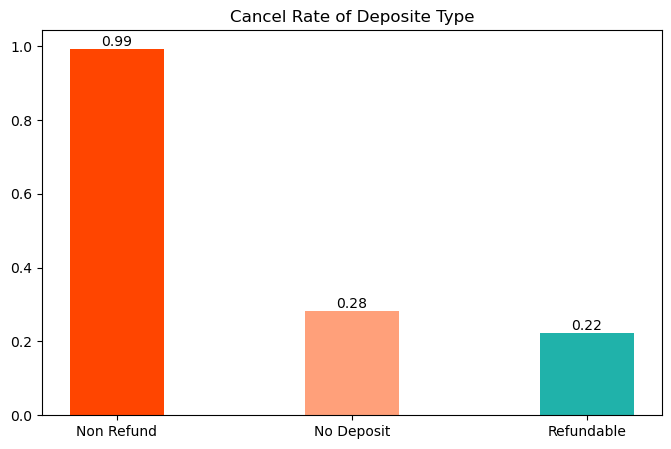

**Finding and Business Impact**

Most bookings use the “No Deposit” policy, while “Refundable” bookings are very limited. However, “Non Refund” bookings show an extremely high cancellation rate, close to 99%, which is significantly higher than the other deposit types.

Deposit policy is strongly associated with cancellation behaviour. The unusually high cancellation rate for “Non Refund” bookings suggests possible issues related to customer behaviour, booking channels, or policy design. Hotels should further review how non-refundable policies are applied and whether they unintentionally increase cancellation risk.

## 2.9 Room Type and Cancellation Behaviour

**Business question:** Are specific room types associated with higher cancellation risk?

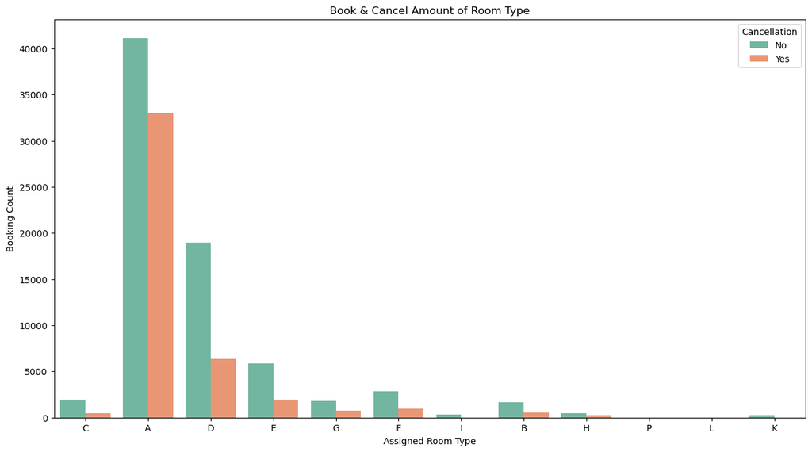

|  | Room Type | Cancellation Rate |
| --- | --- | --- |
| 0 | A | 44.49% |
| 1 | G | 30.55% |
| 2 | E | 25.21% |
| 3 | D | 25.12% |
| 4 | F | 24.71% |
| 5 | B | 23.67% |
| 6 | C | 18.78% |

**Finding and Business Impact**

Room Type A has both the highest booking volume and the highest cancellation rate, at approximately 44.5%. Other room types such as G, E, and D also show relatively high cancellation rates, while Room Type C has the lowest cancellation risk among the major room categories.

Cancellation behaviour differs across room types. High-demand room types such as A and G may require stricter inventory management, pricing controls, or confirmation policies to reduce revenue uncertainty and improve room allocation efficiency.

## 2.10 Business Findings Summary

The exploratory analysis highlights several business-relevant findings:

1. City Hotel shows a significantly higher cancellation rate than Resort Hotel and should be prioritized for cancellation management strategies.
2. Booking demand peaks during July and August, indicating strong seasonality in hotel demand patterns.
3. Major customer source markets are mainly European countries, while Portugal shows the highest cancellation risk among the top markets.
4. Transient customers represent the largest and most valuable customer segment across both hotel types.
5. Online travel agencies are the dominant booking channel, especially for City Hotel bookings.
6. Repeated guests have a much lower cancellation rate than new guests, highlighting the importance of loyalty and retention programs.
7. Deposit policy is strongly associated with cancellation behaviour, with Non Refund bookings showing unusually high cancellation rates.
8. Room Type A has the highest cancellation rate among major room categories and may require stricter booking controls.

These findings suggest that cancellation reduction strategies should be targeted rather than generic. Hotels should apply differentiated management approaches based on hotel type, customer segment, booking channel, source market, deposit policy, and room category.

# 3. Data Preparation for Predictive Analysis

This section prepares the dataset for predictive modelling. Although the main purpose of this report is business analysis, predictive modelling can help management identify bookings with high cancellation probability before the arrival date.

The modelling objective is to predict whether a booking will be cancelled using available reservation and customer information. Fields that directly reveal the final reservation outcome, such as reservation status information, should be treated carefully because they may create data leakage.

The modelling objective is to predict whether a booking will be cancelled using available reservation and customer information. Fields that directly reveal the final reservation outcome, such as reservation status information, should be treated carefully because they may create data leakage.

## 3.1 Categorical Variable Processing

Categorical variables were transformed into numerical representations so that machine learning models could process them effectively.

First, categorical fields in the dataset were identified and reviewed. Missing values in variables such as `agent`, `company`, and `country` were handled using appropriate replacement strategies. For example, missing `country` values were filled using the most frequent country, while missing `agent` and `company` values were replaced with 0 to indicate the absence of an associated booking intermediary.

Several additional business-oriented features were also engineered during this stage. These included:

- `in_company`: whether the booking involved a company
- `in_agent`: whether the booking involved a travel agent
- `same_assignment`: whether the assigned room type matched the reserved room type
- `guest_type`: whether the guest was a repeated customer

After feature engineering, redundant original columns such as `reserved_room_type`, `assigned_room_type`, `agent`, and `company` were removed to reduce duplication and improve dataset clarity.

Finally, categorical variables were encoded into numerical values using Ordinal Encoding, allowing the processed dataset to be used directly for predictive modelling.

|  | hotel | is_canceled | lead_time | arrival_date_year | arrival_date_month | arrival_date_week_number | arrival_date_day_of_month | stays_in_weekend_nights | stays_in_week_nights | adults | ... | days_in_waiting_list | customer_type | adr | required_car_parking_spaces | total_of_special_requests | reservation_status | in_agent | in_company | same_assignment | guest_type |
| --- | --- | --- | --- | --- | --- | --- | --- | --- | --- | --- | --- | --- | --- | --- | --- | --- | --- | --- | --- | --- | --- |
| 0 | 1.0 | 0 | 342 | 2015 | 5.0 | 27 | 1 | 0 | 0 | 2 | ... | 0 | 2.0 | 0.0 | 0 | 0 | 1.0 | 0.0 | 0.0 | 1.0 | 0.0 |
| 1 | 1.0 | 0 | 737 | 2015 | 5.0 | 27 | 1 | 0 | 0 | 2 | ... | 0 | 2.0 | 0.0 | 0 | 0 | 1.0 | 0.0 | 0.0 | 1.0 | 0.0 |
| 2 | 1.0 | 0 | 7 | 2015 | 5.0 | 27 | 1 | 0 | 1 | 1 | ... | 0 | 2.0 | 75.0 | 0 | 0 | 1.0 | 0.0 | 0.0 | 0.0 | 0.0 |
| 3 | 1.0 | 0 | 13 | 2015 | 5.0 | 27 | 1 | 0 | 1 | 1 | ... | 0 | 2.0 | 75.0 | 0 | 0 | 1.0 | 1.0 | 0.0 | 1.0 | 0.0 |
| 4 | 1.0 | 0 | 14 | 2015 | 5.0 | 27 | 1 | 0 | 2 | 2 | ... | 0 | 2.0 | 98.0 | 0 | 1 | 1.0 | 1.0 | 0.0 | 1.0 | 0.0 |

5 rows × 31 columns

## 3.2 Continuous Variable Processing

Continuous variables were prepared for predictive modelling to improve model stability and ensure that features were measured on a comparable scale.

First, the modelling dataset was reviewed to identify numerical variables, excluding the target variable `is_canceled` and the categorical variables that had already been encoded. The only remaining missing value issue was found in the `children` field, which was filled using the most frequent value.

After missing value treatment, all continuous variables were converted to numeric format and standardised using z-score standardisation. This transformation scales each continuous feature to have a mean close to 0 and a standard deviation close to 1.

This step helps reduce the influence of large-scale variables, such as `lead_time` and `adr`, and makes the dataset more suitable for machine learning models.

```
lead_time                         0
arrival_date_year                 0
arrival_date_week_number          0
arrival_date_day_of_month         0
stays_in_weekend_nights           0
stays_in_week_nights              0
adults                            0
children                          4
babies                            0
is_repeated_guest                 0
previous_cancellations            0
previous_bookings_not_canceled    0
booking_changes                   0
days_in_waiting_list              0
adr                               0
required_car_parking_spaces       0
total_of_special_requests         0
dtype: int64
```

## 3.3 Correlation Review and Leakage Consideration

Correlation analysis was conducted to identify variables that are strongly associated with booking cancellation behaviour and to detect potential data leakage risks before predictive modelling.

The results show that several variables have relatively strong relationships with the cancellation outcome. In particular, `deposit_type`, `lead_time`, `same_assignment`, and `total_of_special_requests` demonstrate meaningful associations with booking cancellation behaviour and may provide useful predictive signals for modelling.

However, the variable `reservation_status` shows an extremely high correlation with `is_canceled`. This field is directly linked to the final booking outcome and would not realistically be available at the time a prediction is made. Including it in the model would therefore introduce data leakage and produce unrealistically high model performance.

To ensure that the predictive model reflects real business conditions, `reservation_status` was removed from the modelling dataset before training.

This review step helps improve model reliability and ensures that the final predictive model focuses on variables that would genuinely be available during hotel booking operations.

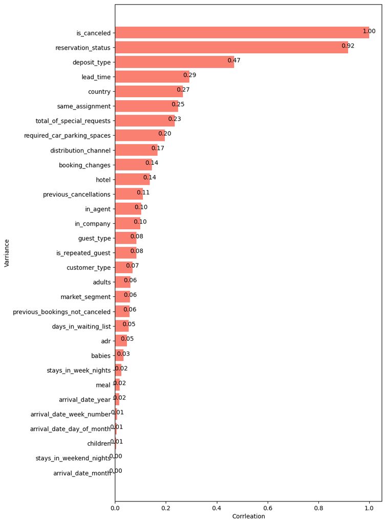

**Modelling Consideration**

`reservation_status` is highly correlated with `is_canceled`, but this field is closely tied to the final outcome and may not be available at prediction time. Including it may cause data leakage and overstate model performance. Therefore, it should be excluded from a realistic predictive model. `deposit_type` and room assignment differences appear more useful for business interpretation and predictive modelling.

# 4. Predictive Modelling Baseline

This section compares several classification models for predicting booking cancellation. The objective is not only to maximize accuracy, but also to understand whether booking-level information can support proactive cancellation risk monitoring.

## 4.1 Random Forest Model

Random Forest was selected as a baseline ensemble learning model because it can capture complex non-linear relationships among booking behaviour, customer characteristics, and operational variables.

The model was trained using 100 decision trees with 10-fold cross-validation to improve robustness and reduce model variance. Predicted probabilities were then used to generate ROC curve analysis and AUC evaluation metrics.

### Model Interpretation

The ROC curve shows that the Random Forest model achieves strong classification performance in distinguishing cancelled bookings from non-cancelled bookings. The curve remains close to the upper-left corner, indicating high recall performance while maintaining relatively low false positive rates.

The AUC score is approximately **0.95**, suggesting that the model has excellent discriminatory capability. This means the model can effectively identify high-risk bookings before arrival.

From a business perspective, the Random Forest model demonstrates that reservation-related information contains meaningful predictive signals for cancellation behaviour. Variables such as deposit policy, booking lead time, customer history, and room assignment consistency likely contribute to the model’s predictive strength.

However, while Random Forest provides strong predictive performance, the model may be less interpretable than simpler statistical approaches because predictions are generated through multiple decision trees rather than a single transparent rule structure.

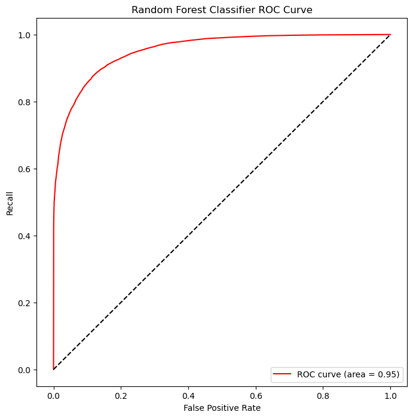

## 4.2 XGBoost Model

XGBoost was introduced as an advanced gradient boosting model to compare against the Random Forest baseline. XGBoost is widely used in structured business datasets because of its ability to optimise predictive accuracy and handle complex feature interactions efficiently.

Before model training, the dataset structure was reviewed to confirm that all variables had been successfully converted into numerical format and that missing value issues had been addressed during preprocessing.

The XGBoost classifier was then trained using the same train-test split and cross-validation strategy applied in the Random Forest experiment. Predicted probabilities were used to generate ROC curve evaluation metrics.

### Model Interpretation

The ROC curve indicates that the XGBoost model achieves very strong predictive performance. The curve remains consistently close to the upper-left corner, showing that the model can maintain high recall while controlling false positive rates effectively.

The AUC score is approximately **0.95**, indicating excellent classification capability and strong separation between cancelled and non-cancelled bookings.

Compared with Random Forest, XGBoost demonstrates similarly high predictive performance while offering stronger optimisation capability and better handling of complex feature interactions. This suggests that booking cancellation behaviour is influenced by multiple interacting operational and customer-related factors rather than isolated variables alone.

From a business perspective, the model confirms that cancellation risk can be predicted using reservation-stage information. This creates opportunities for hotels to apply proactive risk management strategies, such as targeted deposit policies, customer retention campaigns, or operational planning adjustments before guest arrival.

Although both models perform strongly, further feature importance analysis and model explainability techniques would be beneficial to better understand the operational drivers behind cancellation behaviour.

```
<class 'pandas.DataFrame'>
RangeIndex: 83573 entries, 0 to 83572
Data columns (total 29 columns):
 #   Column                          Non-Null Count  Dtype
---  ------                          --------------  -----
 0   hotel                           83573 non-null  float64
 1   lead_time                       83573 non-null  float64
 2   arrival_date_year               83573 non-null  float64
 3   arrival_date_month              83573 non-null  float64
 4   arrival_date_week_number        83573 non-null  float64
 5   arrival_date_day_of_month       83573 non-null  float64
 6   stays_in_weekend_nights         83573 non-null  float64
 7   stays_in_week_nights            83573 non-null  float64
 8   adults                          83573 non-null  float64
 9   children                        83573 non-null  float64
```

[output cut: 21 more lines]

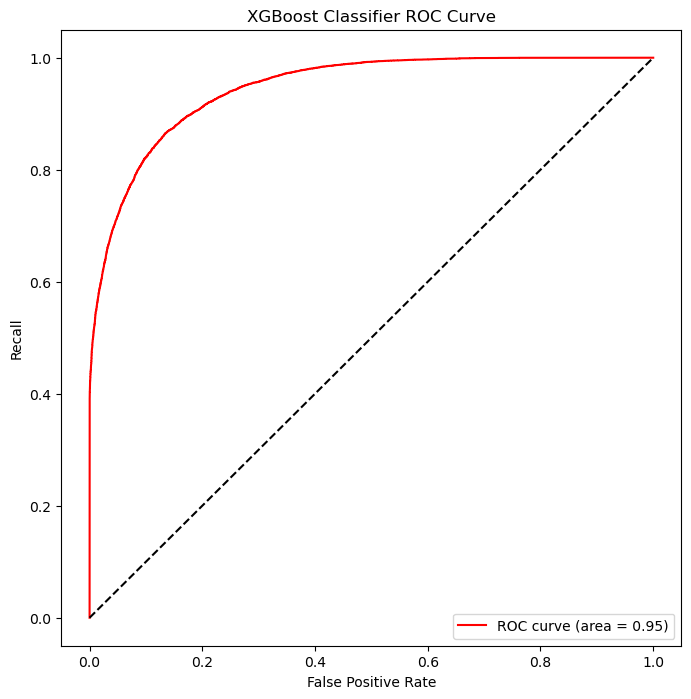

## 4.3 Logistic Regression Model

Logistic Regression was included as an interpretable baseline model for comparison against tree-based models. Unlike Random Forest and XGBoost, Logistic Regression is simpler and easier to explain, making it useful for understanding whether cancellation behaviour can be predicted using a more transparent model.

### Model Interpretation

The Logistic Regression model achieves an AUC score of approximately **0.87**, which indicates strong predictive performance. The ROC curve is clearly above the diagonal baseline, showing that the model can distinguish cancelled bookings from non-cancelled bookings much better than random guessing.

However, its performance is lower than the tree-based models, which achieved AUC scores around **0.95**. This suggests that cancellation behaviour is influenced by complex and non-linear relationships that Logistic Regression cannot fully capture.

From a business perspective, Logistic Regression provides a useful and explainable benchmark model, but tree-based models are more suitable for maximising cancellation prediction performance.

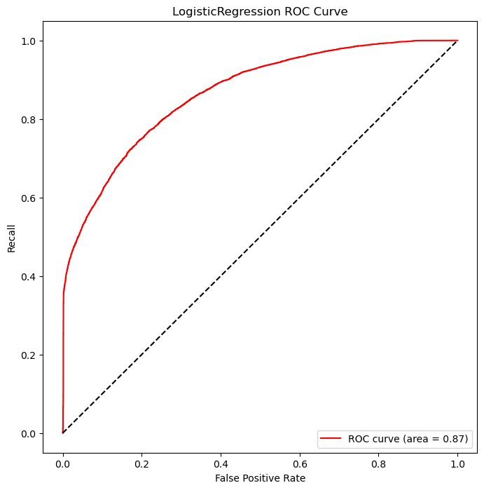

## 4.4 Modelling Summary

The modelling results indicate that tree-based models perform better than Logistic Regression on this dataset. Random Forest achieves strong performance with an accuracy of approximately 88.9% and an AUC of approximately 0.95. This suggests that hotel booking data contains useful signals for cancellation risk prediction.

From a business perspective, such models could be used as a risk scoring tool to flag high-risk bookings for follow-up actions, such as confirmation messages, targeted incentives, or revised deposit policies. However, the model should be validated on future booking data before operational deployment.

```
Random Forest Classification Report
```

|  | precision | recall | f1-score | support |
| --- | --- | --- | --- | --- |
| 0 | 0.894451 | 0.930215 | 0.911983 | 22684.000000 |
| 1 | 0.870522 | 0.810401 | 0.839386 | 13133.000000 |
| accuracy | 0.886283 | 0.886283 | 0.886283 | 0.886283 |
| macro avg | 0.882487 | 0.870308 | 0.875685 | 35817.000000 |
| weighted avg | 0.885677 | 0.886283 | 0.885364 | 35817.000000 |

```
XGBoost Classification Report
```

|  | precision | recall | f1-score | support |
| --- | --- | --- | --- | --- |
| 0 | 0.887662 | 0.914036 | 0.900656 | 22684.000000 |
| 1 | 0.843487 | 0.800198 | 0.821272 | 13133.000000 |
| accuracy | 0.872295 | 0.872295 | 0.872295 | 0.872295 |
| macro avg | 0.865574 | 0.857117 | 0.860964 | 35817.000000 |
| weighted avg | 0.871464 | 0.872295 | 0.871548 | 35817.000000 |

```
Logistic Regression Classification Report
```

|  | precision | recall | f1-score | support |
| --- | --- | --- | --- | --- |
| 0 | 0.795670 | 0.912229 | 0.849972 | 22684.000000 |
| 1 | 0.797044 | 0.595370 | 0.681602 | 13133.000000 |
| accuracy | 0.796047 | 0.796047 | 0.796047 | 0.796047 |
| macro avg | 0.796357 | 0.753800 | 0.765787 | 35817.000000 |
| weighted avg | 0.796174 | 0.796047 | 0.788236 | 35817.000000 |

The classification reports show that the tree-based models outperform Logistic Regression across most evaluation metrics.

Random Forest achieves the strongest balance between precision, recall, and F1-score, especially for cancelled bookings. XGBoost also demonstrates very competitive predictive performance with similar overall results.

Logistic Regression performs reasonably well as a baseline model, but its lower recall and F1-score suggest that cancellation behaviour contains more complex non-linear relationships that are better captured by ensemble tree-based methods.

|  | Accuracy Score | AUC Score |
| --- | --- | --- |
| RandomForest | 0.887918 | 0.954016 |
| XGBoost | 0.874074 | 0.945702 |
| LogisticRegression | 0.796047 | 0.866934 |

### Model Performance Summary

The comparison table indicates that Random Forest achieves the best overall predictive performance, with an accuracy of approximately 88.9% and an AUC score close to 0.95.

XGBoost also performs strongly and demonstrates excellent classification capability on structured hotel reservation data.

Logistic Regression provides a more interpretable baseline model, but its lower predictive performance suggests that hotel cancellation behaviour is influenced by complex interactions among operational and customer-related variables.

Overall, the results indicate that machine learning models can effectively support proactive hotel cancellation risk management and operational decision-making.

# 5. Management Recommendations

The analysis highlights several operational and customer-related factors associated with hotel booking cancellation behaviour. Based on the findings, the following management recommendations are proposed to support revenue protection, operational planning, and customer retention.

## 5.1 Strengthen Cancellation Prevention for City Hotels

City Hotel bookings demonstrate a significantly higher cancellation tendency compared with Resort Hotel bookings. Management should prioritize cancellation reduction initiatives within this segment by improving booking confirmation processes, enhancing customer communication, and introducing targeted retention campaigns for high-risk reservations.

## 5.2 Improve First-Time Guest Engagement

New customers exhibit higher cancellation risk than repeated guests. Hotels should improve onboarding communication for first-time customers by providing clearer booking guidance, automated reminders, and pre-arrival engagement strategies designed to strengthen booking commitment.

## 5.3 Optimize Deposit and Payment Policies

Deposit-related variables show strong relationships with cancellation behaviour. Rather than applying uniform non-refundable policies, management should evaluate more flexible approaches such as staged deposits, partial refund structures, or risk-adjusted payment requirements for selected booking segments.

## 5.4 Enhance Room Information Transparency

Differences between reserved and assigned room types may contribute to customer dissatisfaction and uncertainty before arrival. Hotels should improve room descriptions, pricing transparency, and room assignment consistency to reduce expectation mismatches that may increase cancellation likelihood.

## 5.5 Apply Seasonal Demand Strategies

Booking demand patterns vary across seasonal periods, particularly during peak travel months. Hotels should align pricing, promotional campaigns, and staffing strategies with expected seasonal demand fluctuations to maximize occupancy and operational efficiency.

## 5.6 Develop Predictive Cancellation Monitoring

The predictive modelling results demonstrate that cancellation risk can be estimated from booking-level information. Hotels could operationalize these findings by implementing a booking risk scoring framework that identifies high-risk reservations and triggers proactive intervention actions before cancellation occurs.

# 6. Limitations

Several limitations should be considered when interpreting the findings of this analysis.

First, the analysis is based on historical booking records and therefore may not fully capture future market behaviour or changing customer preferences. External business factors such as economic conditions, airline availability, tourism disruptions, and competitor pricing strategies were not included in the dataset.

Second, some operational variables may contain information that becomes available only after the booking process progresses. Although potential leakage variables such as reservation_status were excluded from predictive modelling, operational deployment would still require careful validation using real-time booking information.

Finally, the dataset does not include customer satisfaction indicators, marketing exposure data, or detailed cancellation reasons. Including these factors in future analysis may further improve predictive performance and business interpretability.

# 7. Conclusion

This business analytics report demonstrates that hotel booking cancellation behaviour can be meaningfully explained using customer, booking, operational, and transactional variables.

The analysis identified several important cancellation drivers, including hotel type, customer history, deposit policy, booking channel characteristics, and room assignment patterns. In addition, the predictive modelling results showed that machine learning approaches — particularly Random Forest and XGBoost — can effectively estimate cancellation risk using booking-level information.

From a business perspective, these findings provide hotels with an opportunity to move from reactive cancellation handling toward proactive risk management. By combining predictive modelling with operational decision-making, hotels may improve occupancy planning, revenue stability, and customer management efficiency.

A practical next step would be to integrate the predictive framework into a dashboard or automated monitoring workflow so that high-risk bookings can be identified and managed before cancellations occur.